[figure not shown]

**Machine Learning**  
MSE FTP MachLe  
Christoph Würsch

# ML07: A3 Support Vector Machine: Pima Indians

MSE_FTP_MachLe, WÜRC

```python
%matplotlib inline
import pandas as pd
import matplotlib.pyplot as plt
import numpy as np
import seaborn as sns
```

## Pima-Indian dataset

The data set `pima-indians-diabetes.csv` contains medical indicators collected from 768 patients of the indigenous Pima tribe (Phoenix, AZ). The subjects were between 21 and 81 years old. The following characteristics were recorded:

- `NumTimesPrg`: Number of pregnancies
- `PlGlcConc`: Blood sugar 2h after oral uptake of sugar (oGTT) (mg/dl)
- `BloodP`: Diastolic blood pressure (mm Hg)
- `SkinThick`: thickness of the skin fold at the triceps (mm)
- `TwoHourSerIns`: Insulin concentration after 2h oGTT ( 𝜇 IU/ mg)
- `BMI`:Body Mass Index (kg/m 2 )
- `DiPedFunc`: Hereditary predisposition
- `Age`: Age (years)
- `HasDiabetes` :Diagnosis Diabetes Type II

The classification goal is to make the diagnosis of type II diabetes based on the factors, i.e. to make a prediction model for the variable `y= HasDiabetes` using a support vector machine (SVM) with a radial basis function kernel.

[figure not shown]

### Explorative Data Analysis (EDA)

Load the dataset `pima-indians-diabetes.csv` and create a `pandas` data frame from it. We take care that the column captions are imported correctly.

```python
pima = pd.read_csv('./pima-indians-diabetes.csv', header=None)
pima.columns = ["NumTimesPrg", "PlGlcConc", "BloodP", "SkinThick", "TwoHourSerIns", "BMI", "DiPedFunc", "Age", "HasDiabetes"]
```

Display the first 5 entries of the dataset.

```python
pima.head(5)
```

|  | NumTimesPrg | PlGlcConc | BloodP | SkinThick | TwoHourSerIns | BMI | DiPedFunc | Age | HasDiabetes |
| --- | --- | --- | --- | --- | --- | --- | --- | --- | --- |
| 0 | 6 | 148 | 72 | 35 | 0 | 33.6 | 0.627 | 50 | 1 |
| 1 | 1 | 85 | 66 | 29 | 0 | 26.6 | 0.351 | 31 | 0 |
| 2 | 8 | 183 | 64 | 0 | 0 | 23.3 | 0.672 | 32 | 1 |
| 3 | 1 | 89 | 66 | 23 | 94 | 28.1 | 0.167 | 21 | 0 |
| 4 | 0 | 137 | 40 | 35 | 168 | 43.1 | 2.288 | 33 | 1 |

It is already noticeable here that the insulin values of some patients have the value '0'.

### (a) Calculate the percentage of patients with diabetes and display a statistics using `df.describe`

We can calculate the percentage of the patients with diabetes by determining the mean value of the response column 'HasDiabetes'. Using the `dataframe.describe()`, we can print the main statistics of the dataset.

```python
perc_diab = pima['HasDiabetes'].mean()

print('percentage of diabetes: %f ' % np.round(perc_diab*100, 2))

y = pima['HasDiabetes']
X = pima.drop('HasDiabetes', axis=1)

X_names = X.columns
```

```
percentage of diabetes: 34.900000
```

```python
pima.describe()
```

|  | NumTimesPrg | PlGlcConc | BloodP | SkinThick | TwoHourSerIns | BMI | DiPedFunc | Age | HasDiabetes |
| --- | --- | --- | --- | --- | --- | --- | --- | --- | --- |
| count | 768.000000 | 768.000000 | 768.000000 | 768.000000 | 768.000000 | 768.000000 | 768.000000 | 768.000000 | 768.000000 |
| mean | 3.845052 | 120.894531 | 69.105469 | 20.536458 | 79.799479 | 31.992578 | 0.471876 | 33.240885 | 0.348958 |
| std | 3.369578 | 31.972618 | 19.355807 | 15.952218 | 115.244002 | 7.884160 | 0.331329 | 11.760232 | 0.476951 |
| min | 0.000000 | 0.000000 | 0.000000 | 0.000000 | 0.000000 | 0.000000 | 0.078000 | 21.000000 | 0.000000 |
| 25% | 1.000000 | 99.000000 | 62.000000 | 0.000000 | 0.000000 | 27.300000 | 0.243750 | 24.000000 | 0.000000 |
| 50% | 3.000000 | 117.000000 | 72.000000 | 23.000000 | 30.500000 | 32.000000 | 0.372500 | 29.000000 | 0.000000 |
| 75% | 6.000000 | 140.250000 | 80.000000 | 32.000000 | 127.250000 | 36.600000 | 0.626250 | 41.000000 | 1.000000 |
| max | 17.000000 | 199.000000 | 122.000000 | 99.000000 | 846.000000 | 67.100000 | 2.420000 | 81.000000 | 1.000000 |

Some characteristics take the value 0, although this makes no medical sense. These are

- `PlGlcConc`
- `BloodP`
- `SkinThick`
- `TwoHourSerins`
- `BMI`

### (b) Exlude samples with zero entries or missing values

Replace the 0 values with `np.nan`and print again a statstical description of the dataset using `df.describe()`. Then drop `np.nan` values using `df.dropna()`.

```python
print(X_names.values)
```

```
['NumTimesPrg' 'PlGlcConc' 'BloodP' 'SkinThick' 'TwoHourSerIns' 'BMI'
 'DiPedFunc' 'Age']
```

```python
pima2 = pima.loc[:,X_names.values]
target= pima['HasDiabetes']
pima2.replace(0, np.nan,inplace=True)
pima2['HasDiabetes']=target

pima2.dropna(axis=0,inplace=True)
pima=pima2
```

```python
pima.describe()
```

|  | NumTimesPrg | PlGlcConc | BloodP | SkinThick | TwoHourSerIns | BMI | DiPedFunc | Age | HasDiabetes |
| --- | --- | --- | --- | --- | --- | --- | --- | --- | --- |
| count | 336.000000 | 336.000000 | 336.000000 | 336.000000 | 336.000000 | 336.000000 | 336.000000 | 336.000000 | 336.000000 |
| mean | 3.851190 | 122.279762 | 70.244048 | 28.663690 | 155.348214 | 32.297321 | 0.518702 | 31.836310 | 0.330357 |
| std | 3.148352 | 30.784649 | 12.363401 | 10.249863 | 118.777281 | 6.368558 | 0.327689 | 10.458446 | 0.471043 |
| min | 1.000000 | 56.000000 | 24.000000 | 7.000000 | 15.000000 | 18.200000 | 0.085000 | 21.000000 | 0.000000 |
| 25% | 1.000000 | 99.000000 | 62.000000 | 21.000000 | 76.000000 | 27.800000 | 0.268000 | 24.000000 | 0.000000 |
| 50% | 3.000000 | 119.000000 | 70.000000 | 28.500000 | 125.500000 | 32.750000 | 0.446500 | 28.000000 | 0.000000 |
| 75% | 6.000000 | 144.000000 | 78.000000 | 36.000000 | 190.000000 | 36.250000 | 0.688250 | 38.000000 | 1.000000 |
| max | 17.000000 | 197.000000 | 110.000000 | 52.000000 | 846.000000 | 57.300000 | 2.329000 | 81.000000 | 1.000000 |

### (c) Plot a histogram of the of each feature and the the target using `df.hist()`

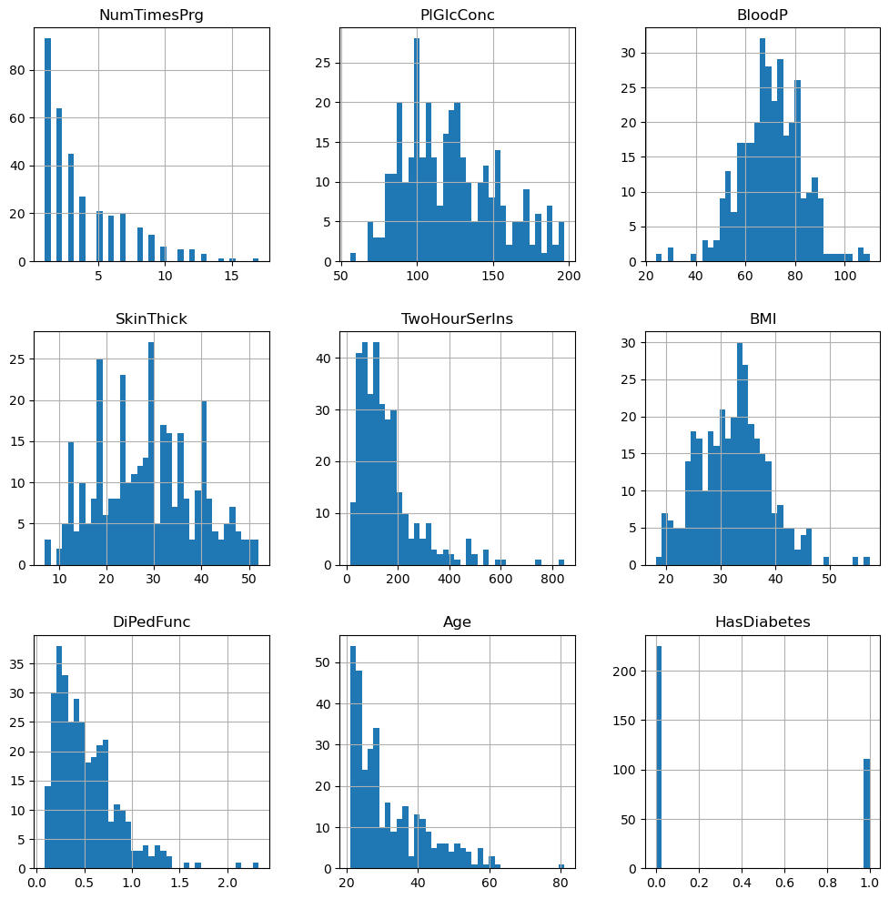

```python
plt.figure()
pima.hist(figsize=(12,12),bins=37)
plt.show()
```

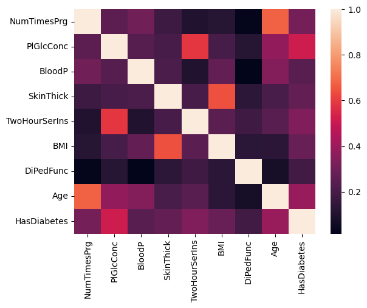

```python
corrmatrix=pima.corr()
import seaborn as sns
corrmatrix
sns.heatmap(corrmatrix)
```

### (d) Split the data in 80% training and 20% test data

Use `train_test_split` from `sklearn.model_selection`. If you feed a `pandas.Dataframe` as an input to the method, you will also get `pandas.Dataframes` as output for the training and test features. This is quite practical.

```python
from sklearn.model_selection import train_test_split

Xtr, Xtest, ytrain, ytest = train_test_split(pima.loc[:,X_names.values],pima.HasDiabetes,train_size=0.8)

Xtr.head()
```

|  | NumTimesPrg | PlGlcConc | BloodP | SkinThick | TwoHourSerIns | BMI | DiPedFunc | Age |
| --- | --- | --- | --- | --- | --- | --- | --- | --- |
| 539 | 3.0 | 129.0 | 92.0 | 49.0 | 155.0 | 36.4 | 0.968 | 32 |
| 503 | 7.0 | 94.0 | 64.0 | 25.0 | 79.0 | 33.3 | 0.738 | 41 |
| 498 | 7.0 | 195.0 | 70.0 | 33.0 | 145.0 | 25.1 | 0.163 | 55 |
| 555 | 7.0 | 124.0 | 70.0 | 33.0 | 215.0 | 25.5 | 0.161 | 37 |
| 420 | 1.0 | 119.0 | 88.0 | 41.0 | 170.0 | 45.3 | 0.507 | 26 |

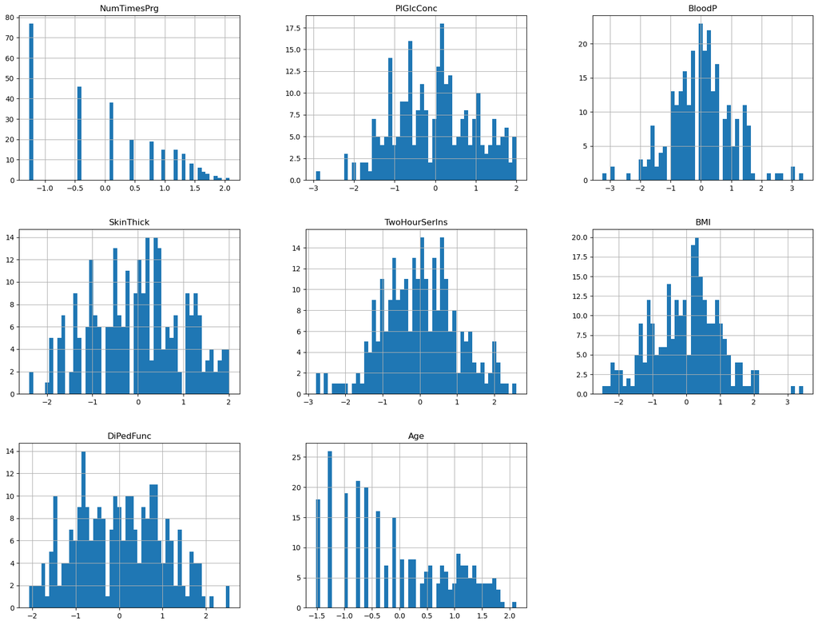

```python
from sklearn.preprocessing import StandardScaler, PowerTransformer

scaler = PowerTransformer()

Xtrain_scale = scaler.fit_transform(Xtr)
Xtest_scale = scaler.transform(Xtest)

Xtrain = pd.DataFrame(Xtrain_scale, columns=X.columns)
Xtrain.hist(bins=50, figsize=(20, 15))
plt.show()
```

### (f) Train a support vector machine with a radial basis function kernel and determine the accuracy on the test data.

```python
from sklearn.svm import SVC
from sklearn.model_selection import StratifiedShuffleSplit
from sklearn.model_selection import GridSearchCV
from sklearn.metrics import accuracy_score

model=SVC(kernel='rbf', gamma=1, C=1)
model.fit(Xtrain, ytrain)
ypred=model.predict(Xtest_scale)
print('Accuracy: %f' % accuracy_score(ytest, ypred))
```

```
Accuracy: 0.691176
```

### (g) Perform a cross validated grid search `GridSearchCV` to find the best parameters for $\gamma$ and $C$ and determine the best parameters and score

- vary the value of $C$ in the range in a logarithmic scale from $10^{-3}$ to $10^{+3}$ (7 steps)
- vary the value of $\gamma$ in the range in a logarithmic scale from $10^{-3}$ to $10^{+3}$ (7 steps)
- print a classification report and a confusion matrix of the best classifier using `classification_report` and `confusion_matrix` from `sklearn.metrics`.

```python
C_range = np.logspace(-3, 3, 7)
gamma_range = np.logspace(-3, 3, 7)
param_grid = dict(gamma=gamma_range, C=C_range)

model=SVC()

cv = StratifiedShuffleSplit(n_splits=5, test_size=0.2, random_state=42)
grid = GridSearchCV(model, param_grid=param_grid, cv=cv,n_jobs=-1)
grid.fit(Xtrain, ytrain)

print("The best parameters are %s with a score of %0.2f"
      % (grid.best_params_, grid.best_score_))
```

```
The best parameters are {'C': 100.0, 'gamma': 0.01} with a score of 0.81
```

```python
from sklearn.metrics import classification_report, confusion_matrix

ypred = grid.best_estimator_.predict(Xtest_scale)
target_names = ['negative', 'positive']
print(classification_report(ytest, ypred, target_names=target_names))
print(confusion_matrix(ytest, ypred))
```

```
              precision    recall  f1-score   support

    negative       0.73      0.84      0.78        43
    positive       0.63      0.48      0.55        25

    accuracy                           0.71        68
   macro avg       0.68      0.66      0.66        68
weighted avg       0.70      0.71      0.70        68

[[36  7]
 [13 12]]
```

### (h) Plot the resulting decision boundary of the SVM classifier for different values of $\gamma$ and $C$ as contour plot in 2D

Use the following features as the only features for the prediction such that we can display the decision boundary in a 2D plot.

- feature 1: `TwoHourSerIns` (x1-axis)
- feature 2: `Age` (x2-axis)

Vary the C parameters in the following ranges:

- `C_range = [1e-2, 1, 1e2]`
- `gamma_range = [1e-1, 1, 1e1]`

You can use the helper function `PlotDecisionBoundary(model, X2D, y)` to plot the decision boundary and the margins of the classifier.

```python
print(X_names.values)

Xtrain_2D=Xtrain.loc[:,['TwoHourSerIns','Age']]
Xtrain_2D
```

```
['NumTimesPrg' 'PlGlcConc' 'BloodP' 'SkinThick' 'TwoHourSerIns' 'BMI'
 'DiPedFunc' 'Age']
```

|  | TwoHourSerIns | Age |
| --- | --- | --- |
| 0 | 0.338792 | 0.393584 |
| 1 | -0.598462 | 1.093503 |
| 2 | 0.245121 | 1.660801 |
| 3 | 0.801149 | 0.832773 |
| 4 | 0.468854 | -0.410964 |
| ... | ... | ... |
| 263 | 0.092171 | 0.756580 |
| 264 | 1.373547 | 1.034186 |
| 265 | -0.547199 | -0.788200 |
| 266 | -0.844745 | -0.590624 |
| 267 | 0.903177 | 0.285078 |

268 rows × 2 columns

```python
def PlotDecisionBoundary(model, X2D, y):

    gamma=model.gamma
    C=model.C
    x1=X2D.iloc[:,0].values
    x2=X2D.iloc[:,1].values

    # evaluate decision function in a grid
    xx, yy = np.meshgrid(np.linspace(-2, 2, 200), np.linspace(-2, 2, 200))

    Z = clf.decision_function(np.c_[xx.ravel(), yy.ravel()])
    Z = Z.reshape(xx.shape)

    # visualize decision function for these parameters

    plt.title("gamma=10^%d, C=10^%d" % (np.log10(gamma), np.log10(C)),
            size='medium')

    # visualize parameter's effect on decision function
    plt.pcolormesh(xx, yy, -Z, cmap=plt.cm.RdBu,shading='nearest')
    plt.contour(xx, yy, -Z,[-1, 0, 1])
    plt.scatter(x1, x2, c=y, cmap=plt.cm.RdBu_r, edgecolors='k')
    plt.xlim([-2,2])
    plt.ylim([-2,2])
```

```python
# Now we need to fit a classifier for all parameters in the 2d version
# (we use a smaller set of parameters here because it takes a while to train)

C_range = [1e-2, 1, 1e2]
gamma_range = [1e-1, 1, 1e1]
classifiers = []
for C in C_range:
    for gamma in gamma_range:
        clf = SVC(kernel='rbf', degree=2, C=C, gamma=gamma)
        clf.fit(Xtrain_2D.values, ytrain)
        classifiers.append((C, gamma, clf))
```

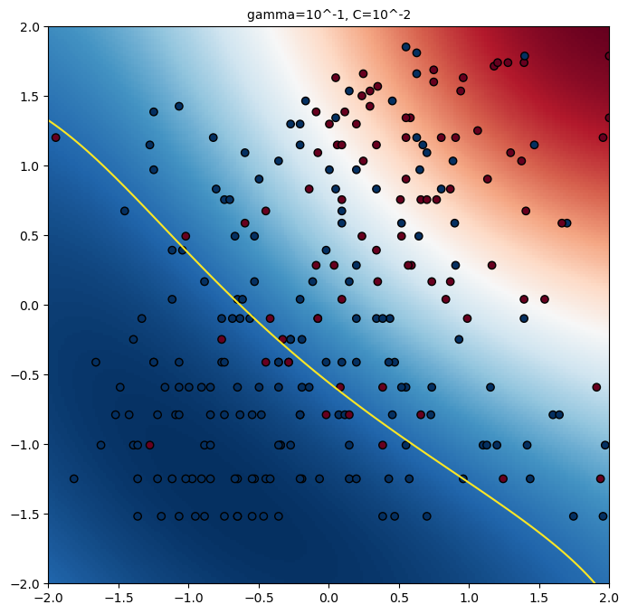

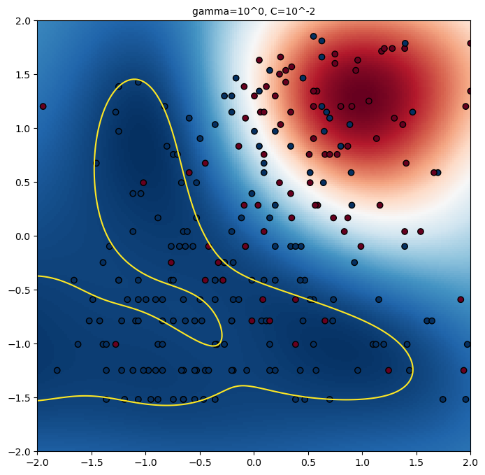

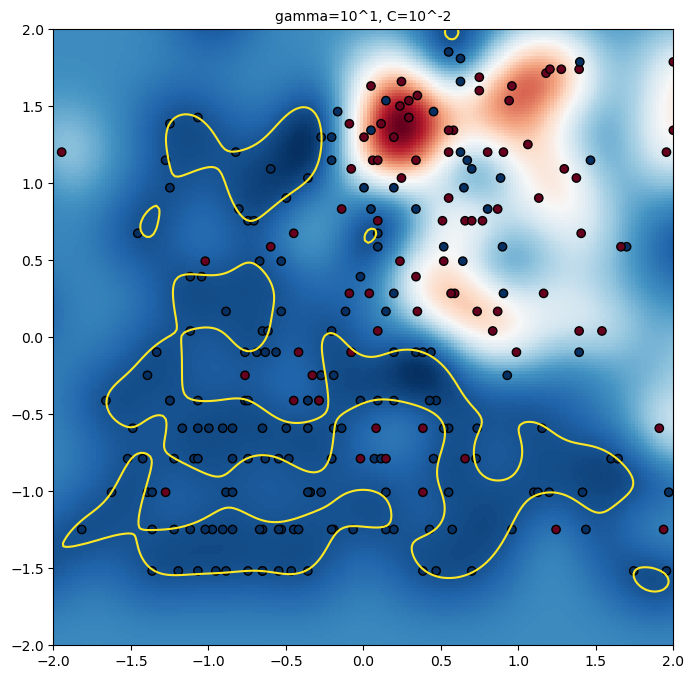

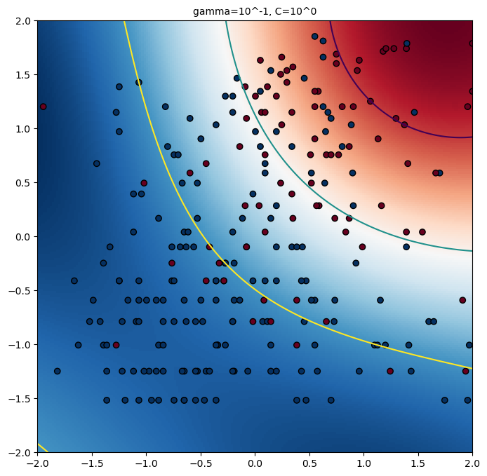

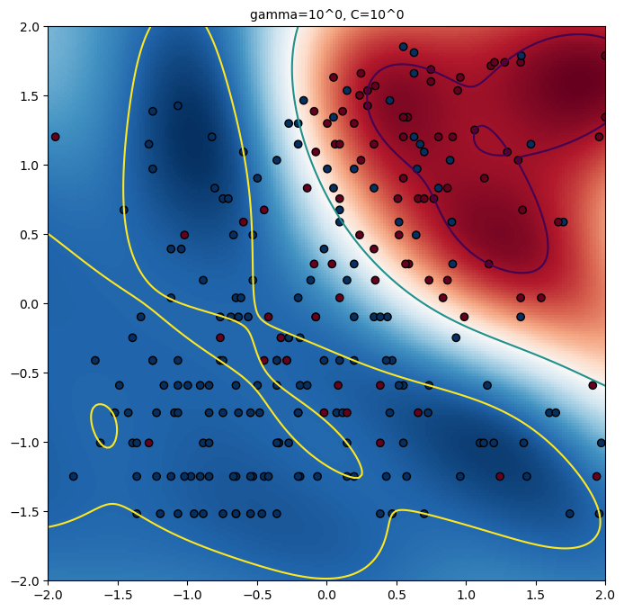

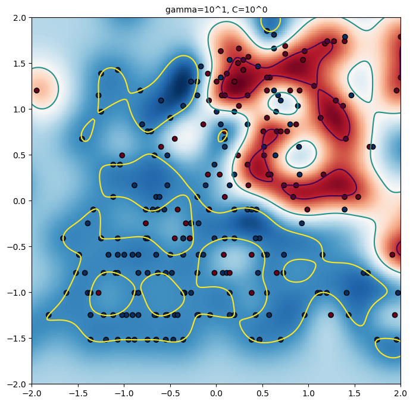

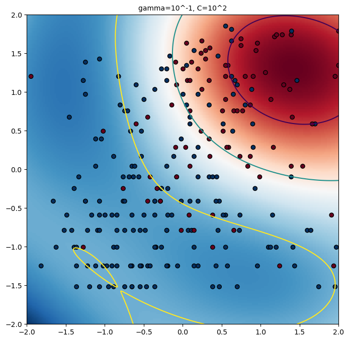

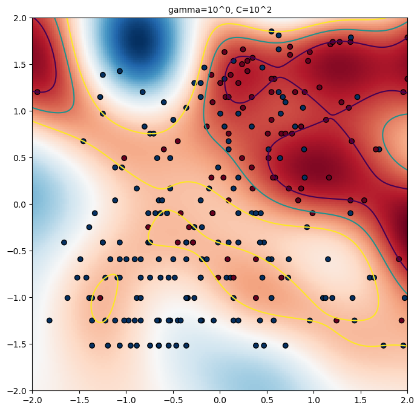

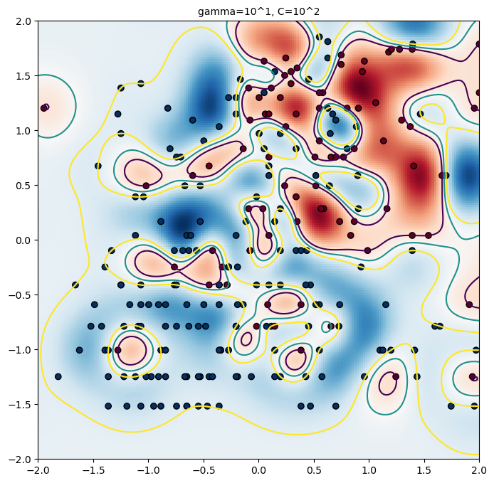

```python
# #############################################################################
# Visualization
#
# draw visualization of parameter effects


for (k, (C, gamma, clf)) in enumerate(classifiers):

    plt.figure(figsize=(8, 8))
    # visualize decision function for these parameters
    # plt.subplot(len(C_range), len(gamma_range), k + 1)
    PlotDecisionBoundary(clf, Xtrain_2D, ytrain)
#plt.savefig('diabetes.pdf')
```